# R Markdown HW

heyEddie23

10/3/2021

# Overview

The purpose of this tutorial is perform a one sample t-test using the *Mtcars* data in R. By the end of the tutorial, you should be able to:

- Display the data graphically.
- Check assumptions for a one-sample t-test.
- Perform and interpret a one-sample t-test.

#### The Dataset: *Motor Trend Car Road Tests*

The data was extracted from the 1974 Motor Trend US magazine, and comprises fuel consumption and 10 aspects of automobile design and performance for 32 automobiles (1973–74 models).

[figure not shown]

https://www.motortrend.com/

[Practice](https://heyeddie23.github.io/practice)

## Question

Is the average miles per gallon for the vehicles better than 22 mpg?

### Hypotheses

#### Null

$H_0: \mu = 22$  
The true population mean miles per gallon for the vehicles is 22 mpg.

#### Alternative

$H_A: \mu > 22$  
The true population mean miles per gallon for the vehicles is greater than 22 mpg.

### The Data

*Mtcars* is a dataset that comes with R. Simply type *mtcars* and you can view the data.

```r
mtcars
```

[output not shown]

## Calculations

### Step 1: Examine the data.

##### We will begin by examining the first five rows of the dataset. Let’s see how many data lines and variables are in the data.

|  | mpg | cyl | disp | hp | drat | wt | qsec | vs | am | gear | carb |
| --- | --- | --- | --- | --- | --- | --- | --- | --- | --- | --- | --- |
| Mazda RX4 | 21.0 | 6 | 160 | 110 | 3.90 | 2.620 | 16.46 | 0 | 1 | 4 | 4 |
| Mazda RX4 Wag | 21.0 | 6 | 160 | 110 | 3.90 | 2.875 | 17.02 | 0 | 1 | 4 | 4 |
| Datsun 710 | 22.8 | 4 | 108 | 93 | 3.85 | 2.320 | 18.61 | 1 | 1 | 4 | 1 |
| Hornet 4 Drive | 21.4 | 6 | 258 | 110 | 3.08 | 3.215 | 19.44 | 1 | 0 | 3 | 1 |
| Hornet Sportabout | 18.7 | 8 | 360 | 175 | 3.15 | 3.440 | 17.02 | 0 | 0 | 3 | 2 |

```
## [1] "There are 32 rows of data and  11 variables."
```

### Step 2: Check condtions/assumptions.

#### Conditions

The following conditions should be checked to use a one-sample t-test:

1. Randomization
- Was the data randomly selected?
2. Continuity
- Is the response variable continuous?
3. Independence
- Are the observations are independent of one another?
4. Normality
- Is the response variable normally distributed?
- Does the data contain any extreme outliers?

#### Boxplot

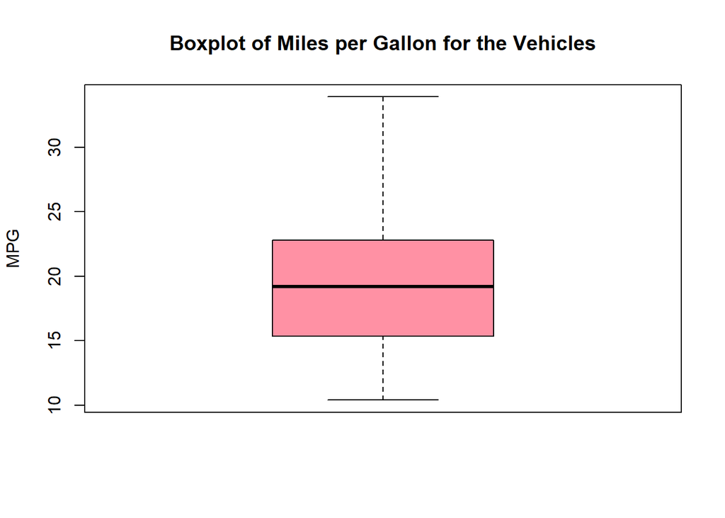

```r
boxplot(mtcars$mpg, main="Boxplot of Miles per Gallon for the Vehicles",
        col="#ff91a4", ylab="MPG")
```

#### Summary

```
##    Min. 1st Qu.  Median    Mean 3rd Qu.    Max.
##   10.40   15.43   19.20   20.09   22.80   33.90
```

```
## [1] "Sample size, n =  32"
```

#### Histogram

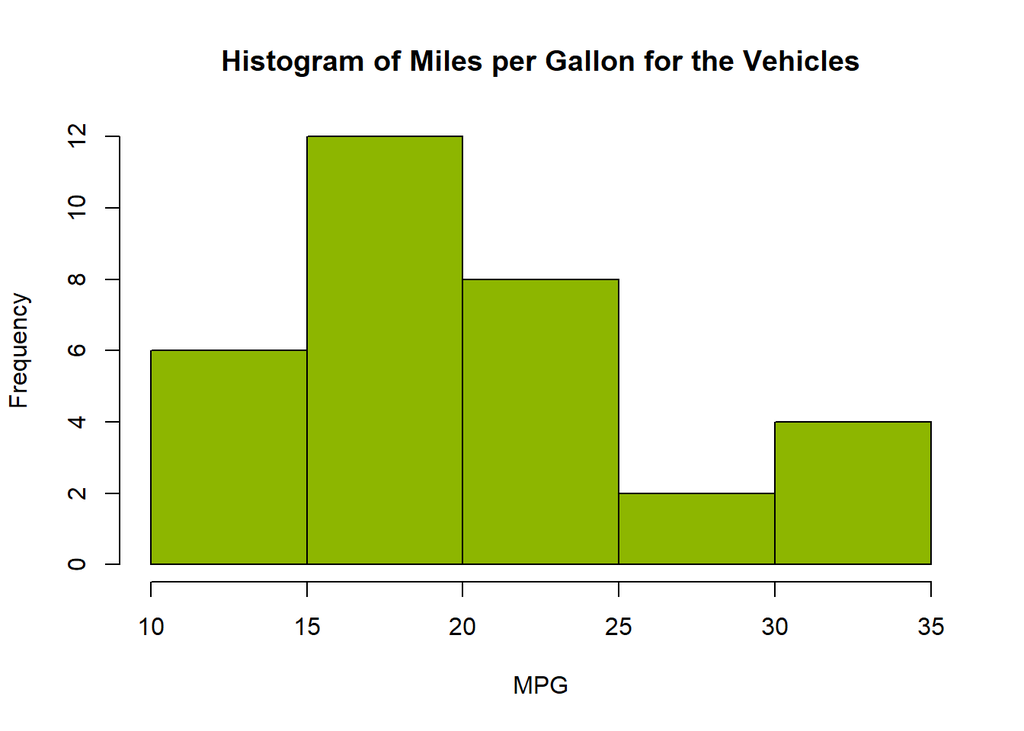

```r
hist(mtcars$mpg, main="Histogram of Miles per Gallon for the Vehicles", xlab = "MPG", col="#8DB600")
```

#### Q-Q Plot

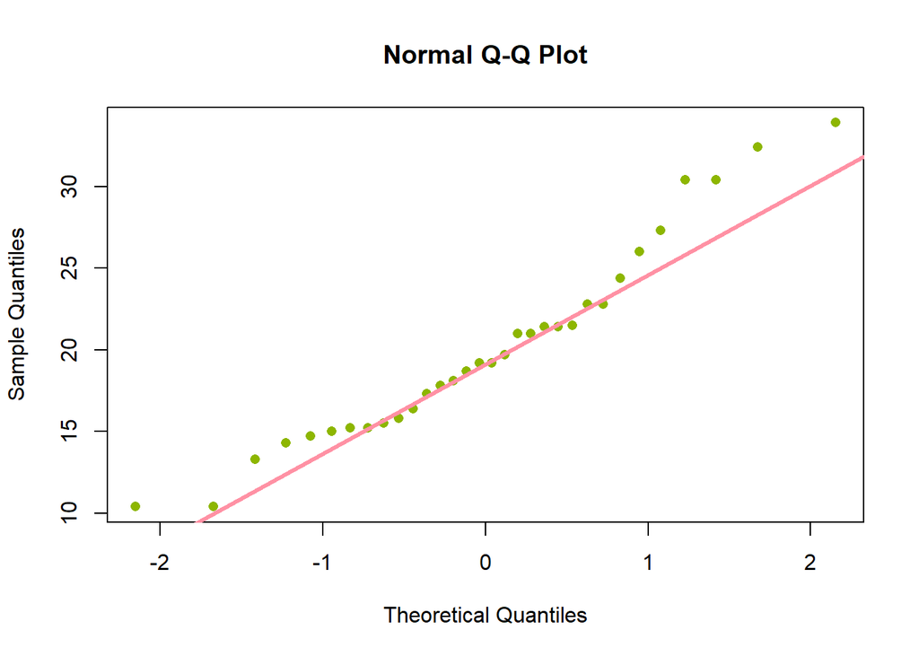

```r
qqnorm(mtcars$mpg, col="#8DB600", pch=16)
qqline(mtcars$mpg, col="#ff91a4", lwd=3)
```

#### Check Conditions

- Randomly selected *It is unclear how the data were selected. We will assume the data is representative of the population.*
- Continuous
- Independent
- Normally distributed *The sample size is greater than 30 and the data is slightly skewed. T-test are robust to normality, therefore we will proceed with a one-sample t-test.*

### Step 3: Perform t-test

```r
carsttest<-t.test(mtcars$mpg, alternative = "greater", mu=22); carsttest
```

```
##
##  One Sample t-test
##
## data:  mtcars$mpg
## t = -1.7921, df = 31, p-value = 0.9586
## alternative hypothesis: true mean is greater than 22
## 95 percent confidence interval:
##  18.28418      Inf
## sample estimates:
## mean of x
##  20.09062
```

## Interpretation

Using a one-sample t-test, there is insufficient evidence ( t = -1.792127, df = 31, p = 0.9586, $\alpha$ = 0.05) to reject the null hypothesis, therefore we cannot conclude that the true population mean miles per gallon is greater than 22 mpg.

## Extras

### Appearance

The overall look of the html output can be modified with pre-packaged themes. The theme I chose was “cerulean.” The most noticeable difference is the font color. The color for the headers changed from black to cerulean.

I ‘highlighted’ the code which makes it easier to determine what is a command versus a variable.

I highlight certain chunks of text to bring attention to it or emphasize it as important. I did that on my objectives for this assignment.

I also added a checklist as well.

### Code Folding

I included this feature because some of my code was long, and it seems like a nice way to keep things aesthetically appealing.

### Tabs

Tabs can be added to the R Markdown html. This feature helps to shorten the document, condense topics, and group examples.

### Conclusion

[figure not shown]